# Trabajo Practico Final - Ciencia de Datos II

Silvia Prevettoni

2025-08-22

# **Accesibilidad territorial a servicios de salud en Villa Jardín - Partido de Lanus - Análisis Geográfico**

En la actualidad, se estima que uno de cada diez habitantes en Argentina reside en un barrio popular. Cada vez más, la exclusión social y la segregación territorial de gran parte de la sociedad incrementan la desigualdad que ha caracterizado al país durante los últimos 40 años. Como primera mirada, los barrios populares del país se caracterizan por la coexistencia de los siguientes factores:

- Altos niveles de hacinamiento.
- Falta de acceso por parte de sus habitantes a servicios básicos (agua, electricidad, cloacas y gas) y un fuerte predominio de redes de conexiones informales, debido a la ausencia del Estado y de empresas prestatarias.
- Prevalencia de la autoconstrucción habitacional y ubicación en lotes con tenencia de la tierra irregular o no regularizada, frecuentemente situados cerca de zonas expuestas a diversas clases de riesgos ambientales.

Sin embargo, un cambio crucial ocurrió en 2016 con el inicio de un relevamiento de información básica a través del Registro Nacional de Barrios Populares (ReNaBap). Este proyecto no sólo impulsó un marco normativo que permitió definir y delimitar estos territorios de manera concreta, sino que también sistematizó datos para crear estadísticas públicas sobre estas familias y sus tierras. Por lo tanto, el proyecto que presento identifica y cuantifica los barrios populares a nivel nacional, mostrando la distribución de los barrios en el ámbito nacional y seleccionando el partido de Lanús (selección basada en mi residencia). En base a esto, las preguntas de investigación que se plantean son:

¿Cuál es la localidad que tiene mayor predominio de barrios populares y dentro de esa localidad, ¿cuál es el barrio que tiene mayor cantidad de familias y viviendas?

¿Cuál es el nivel de accesibilidad a los centros de salud que tiene el barrio seleccionado?

Para comenzar, procedemos a activar las librerías;

```r
library(tidyverse)
library(dplyr)
library(sf)
library(osrm)
library(tidygeocoder)
library(leaflet)
library(ggmap)
library(lubridate)
library(osmdata)
```

```r
library(ggplot2)
```

El primer dataset corresponde a la base de datos del Renabap y a modo de introducción presento los datos de barrios populares de la República Argentina;

```r
popular <- st_read("Datos/renabap-datos-barrios-gpkg",
               stringsAsFactors = TRUE, options = "ENCODING=UTF-8")
```

```
## options:        ENCODING=UTF-8
```

Exploramos el contenido:

```r
dim(popular)
```

```
## [1] 6467   18
```

El dataset inicial cuenta con 6467 registros y 18 variables.

Los nombres de las variables son las siguientes;

```r
names(popular)
```

```
##  [1] "id_renabap"                     "nombre_barrio"
##  [3] "provincia"                      "departamento"
##  [5] "localidad"                      "cantidad_viviendas_aproximadas"
##  [7] "cantidad_familias_aproximada"   "decada_de_creacion"
##  [9] "anio_de_creacion"               "energia_electrica"
## [11] "efluentes_cloacales"            "agua_corriente"
## [13] "cocina"                         "calefaccion"
## [15] "titulo_propiedad"               "clasificacion_barrio"
## [17] "superficie_m2"                  "geom"
```

Vemos el resumen estadístico:

```r
summary(popular)
```

```
##    id_renabap           nombre_barrio         provincia
##  Min.   :   1   Sin Nombre     : 171   Buenos Aires:2065
##  1st Qu.:1778   San Cayetano   :  40   Santa Fe    : 469
##  Median :3564   La Esperanza   :  35   Chaco       : 442
##  Mean   :3505   San Martín     :  32   Misiones    : 413
##  3rd Qu.:5244   Nueva Esperanza:  29   Tucumán     : 370
##  Max.   :6866   San José       :  27   Mendoza     : 360
##                 (Other)        :6133   (Other)     :2348
##                      departamento                  localidad
##  Capital                   : 610   Córdoba Capital      : 177
##  San Fernando              : 220   Rosario              : 119
##  Rosario                   : 175   Resistencia          : 105
##  La Plata                  : 166   San Miguel De Tucumán:  81
##  La Matanza                : 163   Posadas              :  76
##  General José de San Martín: 139   Corrientes           :  74
##  (Other)                   :4994   (Other)              :5835
##  cantidad_viviendas_aproximadas cantidad_familias_aproximada
##  Min.   :    5.0                Min.   :    6.0
##  1st Qu.:   30.0                1st Qu.:   33.0
##  Median :   70.0                Median :   77.0
##  Mean   :  173.9                Mean   :  191.4
##  3rd Qu.:  167.0                3rd Qu.:  184.0
##  Max.   :14000.0                Max.   :15400.0
##
##    decada_de_creacion anio_de_creacion
##  Década 2000:1735     Min.   :2010
##  Década 2010:1604     1st Qu.:2012
##  Década 1990: 995     Median :2014
##  Década 1980: 790     Mean   :2014
##  Década 1970: 472     3rd Qu.:2016
##  Década 1960: 361     Max.   :2021
##  (Other)    : 510     NA's   :4779
##                                                            energia_electrica
##  Conexión irregular a la red                                        :3670
##  Conexión formal a la red con medidor domiciliario con factura      :2187
##  Conexión a la red con medidor comunitario                          : 194
##  Conexión regular a la red con medidor domiciliario pero sin factura: 117
##  No tiene conexión eléctrica                                        : 104
##  Conexión a la red con medidor compartido                           :  85
##  (Other)                                                            : 110
```

[output cut: 33 more lines]

```
##  Asentamiento                     :5253      Min.   :    368
##  Conjunto habitacional unifamiliar:  87      1st Qu.:  18385
##  Villa                            :1127      Median :  46445
##                                              Mean   : 105799
##                                              3rd Qu.: 109727
##                                              Max.   :9715558
##
##             geom
##  MULTIPOLYGON :6467
##  epsg:4326    :   0
##  +proj=long...:   0
##
##
##
##
```

Podemos ver lo siguiente:

- La clasificación de barrio popular con mas registros es el asentamiento con un total de 5,253 registros.
- La mayor cantidad de viviendas en un barrio asciende a 14000 mientras que la menor es de 5.
- El barrio más poblado cuenta con 15400 familias, en contraste con el menos poblado, que tiene apenas 6.
- La década en la que se creo la mayor cantidad de barrios fue la del 2000.

y también podemos utilzar la función class para ver la clase de datos del dataset.

```r
class(popular)
```

```
## [1] "sf"         "data.frame"
```

Se trata de un dataset espacial tipo “sf” compuesto por geometrías bidimensionales multipolígono, como bien indica la última columna geometry.

Luego podemos ver la clase de cada variable;

```r
str(popular)
```

```
## Classes 'sf' and 'data.frame':   6467 obs. of  18 variables:
##  $ id_renabap                    : int  1 2 3 4 5 6 7 8 10 11 ...
##  $ nombre_barrio                 : Factor w/ 4393 levels "10 Hectáreas",..: 2815 2663 1636 2047 717 2074 45 2041 1765 38 ...
##  $ provincia                     : Factor w/ 24 levels "Buenos Aires",..: 1 1 1 1 1 1 1 1 1 1 ...
##  $ departamento                  : Factor w/ 320 levels "1° de Mayo","12 de Octubre",..: 226 167 167 167 167 167 167 167 167 167 ...
##  $ localidad                     : Factor w/ 998 levels "25 De Mayo","28 De Noviembre",..: 670 429 32 862 162 549 549 367 429 425 ...
##  $ cantidad_viviendas_aproximadas: int  40 290 133 122 20 12 23 200 110 59 ...
##  $ cantidad_familias_aproximada  : int  44 319 146 134 22 13 25 220 121 65 ...
##  $ decada_de_creacion            : Factor w/ 13 levels "Década 1900",..: 10 10 11 8 11 8 9 7 11 9 ...
##  $ anio_de_creacion              : int  NA NA NA NA NA NA NA NA NA NA ...
##  $ energia_electrica             : Factor w/ 10 levels "Conexión a la red con medidor compartido",..: 7 4 4 4 4 4 3 4 4 4 ...
##  $ efluentes_cloacales           : Factor w/ 8 levels "Baño seco","Biodigestor para tratar efluentes cloacales",..: 5 5 7 7 5 7 7 5 7 7 ...
##  $ agua_corriente                : Factor w/ 10 levels "Acarreo de baldes/recipientes desde fuera del barrio",..: 3 7 6 7 3 7 3 7 7 7 ...
##  $ cocina                        : Factor w/ 5 levels "Conexión formal a la red de gas con factura",..: 4 4 4 4 4 4 4 4 4 4 ...
##  $ calefaccion                   : Factor w/ 7 levels "Conexión formal a la red de gas con factura",..: 7 6 6 3 7 3 7 3 7 3 ...
##  $ titulo_propiedad              : Factor w/ 2 levels "NO","SI": 1 1 1 1 1 1 1 1 1 1 ...
##  $ clasificacion_barrio          : Factor w/ 3 levels "Asentamiento",..: 1 1 1 1 1 1 1 3 1 1 ...
##  $ superficie_m2                 : int  11674 98093 75887 36889 25768 3424 12698 55095 37429 42326 ...
##  $ geom                          :sfc_MULTIPOLYGON of length 6467; first list element: List of 1
##   ..$ :List of 1
##   .. ..$ : num [1:15, 1:2] -58.8 -58.8 -58.8 -58.8 -58.8 ...
##   ..- attr(*, "class")= chr [1:3] "XY" "MULTIPOLYGON" "sfg"
##  - attr(*, "sf_column")= chr "geom"
##  - attr(*, "agr")= Factor w/ 3 levels "constant","aggregate",..: NA NA NA NA NA NA NA NA NA NA ...
##   ..- attr(*, "names")= chr [1:17] "id_renabap" "nombre_barrio" "provincia" "departamento" ...
```

Visualizamos los datos;

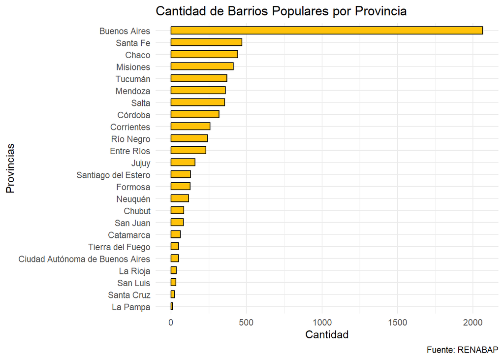

```r
ggplot(popular, aes(x = fct_reorder(provincia, provincia, .fun = length))) +
  geom_bar(color = "black", fill = "#ffc20a", width=0.6) +
  labs(title = "Cantidad de Barrios Populares por Provincia",
  x="Provincias",
  y="Cantidad",
  caption = "Fuente: RENABAP")+
  theme(axis.text.x = element_text(angle = 90, hjust = 1)) +
  theme_minimal() +
  coord_flip()
```

El gráfico evidencia que la mayor concentración de barrios populares se encuentran en la provincia de Buenos Aires y luego en las provincias de Santa Fe, Chaco, Misiones y Tucumán.

La provincia de Buenos Aires es el foco de nuestro interés. Al contar con más de 2,000 registros decidí reducir la muestra limitándola a los partidos con más de 3,000 familias.

Filtre el dataset para seleccionar aquellos partidos donde la cantidad de familias supera las 3,000 familias.

```r
popuBue <-  popular %>%
filter(provincia=="Buenos Aires",
       cantidad_familias_aproximada >3000)
```

Vemos la cantidad de registros y columnas.

```r
dim (popuBue)
```

```
## [1] 13 18
```

En este dataset tenemos 13 registros con 18 variables.

Pasamos a visualizarla;

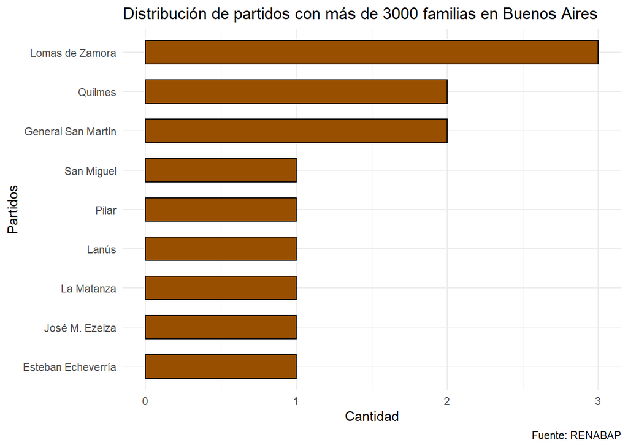

```r
ggplot(popuBue, aes(x = fct_reorder(departamento, departamento, .fun = length))) +
  geom_bar(color = "black", fill = "#994f00", width=0.6) +
  labs(title = "Distribución de partidos con más de 3000 familias en Buenos Aires",
  x="Partidos",
  y= "Cantidad",
  caption = "Fuente: RENABAP")+
  theme(axis.text.x = element_text(angle = 0, hjust = 1),
        axis.text.y.right = element_text()) +
  theme_minimal() +
  coord_flip()
```

Ahora si, seleccionamos el partido de Lanús.

Filtramos el partido para analizar sus variables y buscar la respuesta a las preguntas planteadas en el proyecto.

```r
popular_Lanus <- popular %>%
  filter(departamento == "Lanús")
```

Verificamos que el dataset solo muestra los barrios de la localidad.

```r
head(popular_Lanus)
```

```
## Simple feature collection with 6 features and 17 fields
## Geometry type: MULTIPOLYGON
## Dimension:     XY
## Bounding box:  xmin: -58.4242 ymin: -34.73449 xmax: -58.36054 ymax: -34.6604
## Geodetic CRS:  WGS 84
##   id_renabap         nombre_barrio    provincia departamento
## 1        141            Los Ceibos Buenos Aires        Lanús
## 2        167              Campomar Buenos Aires        Lanús
## 3        181             Rivadavia Buenos Aires        Lanús
## 4        187 San Francisco de Asís Buenos Aires        Lanús
## 5        403              Talleres Buenos Aires        Lanús
## 6        454          Villa Sapito Buenos Aires        Lanús
##              localidad cantidad_viviendas_aproximadas
## 1       Monte Chingolo                            750
## 2      Valentín Alsina                             35
```

[output cut: 53 more lines]

Revisamos los resultados.

```r
dim(popular_Lanus)
```

```
## [1] 26 18
```

El dataset tiene 26 registros y 18 columnas.

```r
summary(popular_Lanus)
```

```
##    id_renabap         nombre_barrio                           provincia
##  Min.   : 141   ACUBA        : 1    Buenos Aires                   :26
##  1st Qu.:1012   Balcarce     : 1    Catamarca                      : 0
##  Median :1261   Campomar     : 1    Chaco                          : 0
##  Mean   :2114   Diez de Enero: 1    Chubut                         : 0
##  3rd Qu.:2942   Esperanza    : 1    Ciudad Autónoma de Buenos Aires: 0
##  Max.   :6372   Eva Perón    : 1    Córdoba                        : 0
##                 (Other)      :20    (Other)                        : 0
##         departamento                localidad cantidad_viviendas_aproximadas
##  Lanús        :26    Lanús Oeste         :9   Min.   :  18.0
##  1° de Mayo   : 0    Valentín Alsina     :6   1st Qu.: 150.0
##  12 de Octubre: 0    Monte Chingolo      :4   Median : 355.0
##  2 de Abril   : 0    Remedios De Escalada:4   Mean   : 600.7
##  25 de Mayo   : 0    Lanús Este          :3   3rd Qu.: 725.0
##  9 de Julio   : 0    25 De Mayo          :0   Max.   :4500.0
##  (Other)      : 0    (Other)             :0
##  cantidad_familias_aproximada   decada_de_creacion anio_de_creacion
##  Min.   :  20.0               Década 1970:6        Min.   : NA
##  1st Qu.: 165.0               Década 1980:5        1st Qu.: NA
##  Median : 390.5               Década 2000:5        Median : NA
##  Mean   : 660.8               Década 1960:3        Mean   :NaN
##  3rd Qu.: 797.5               Década 1990:3        3rd Qu.: NA
##  Max.   :4950.0               Década 1940:2        Max.   : NA
##                               (Other)    :2        NA's   :26
##                                                      energia_electrica
##  Conexión irregular a la red                                  :18
##  Conexión formal a la red con medidor domiciliario con factura: 5
##  Conexión a la red con medidor comunitario                    : 1
##  Conexión regular a la red con medidor prepago                : 1
##  No tiene conexión eléctrica                                  : 1
##  Conexión a la red con medidor compartido                     : 0
##  (Other)                                                      : 0
##                              efluentes_cloacales
##  Desagüe sólo a pozo negro/ciego u hoyo:12
##  Desagüe a cámara séptica y pozo ciego : 7
##  Conexión formal a la red cloacal      : 3
##  Conexión irregular a la red cloacal   : 2
##  Red cloacal conectada a la red pluvial: 2
##  Baño seco                             : 0
##  (Other)                               : 0
```

[output cut: 25 more lines]

```
##  Asentamiento                     : 7        Min.   :  3049
##  Conjunto habitacional unifamiliar: 0        1st Qu.: 18130
##  Villa                            :19        Median : 52981
##                                              Mean   : 92235
##                                              3rd Qu.: 68818
##                                              Max.   :426815
##
##             geom
##  MULTIPOLYGON :26
##  epsg:4326    : 0
##  +proj=long...: 0
##
##
##
##
```

Grafiquemos algunas variables de interés;

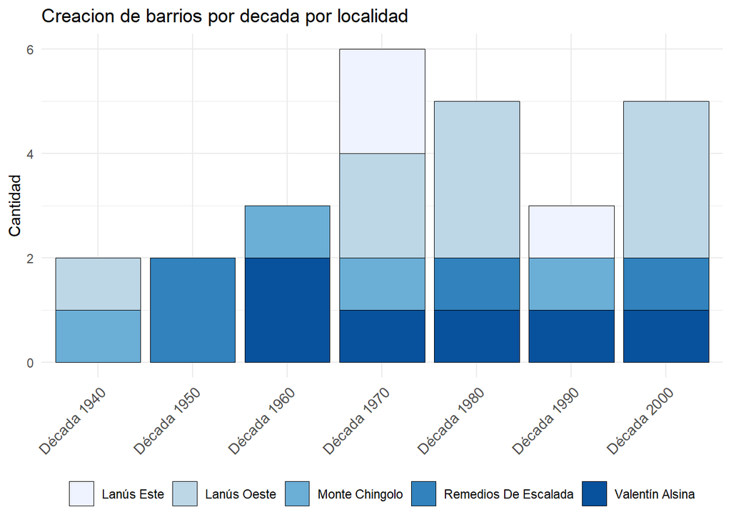

```r
ggplot() +
    geom_bar(data= popular_Lanus, aes(x = decada_de_creacion, fill=localidad),
             color = "black",
             linewidth = 0.2)+
  scale_fill_brewer() +
    labs(
    x = NULL,
    y = "Cantidad",
    fill = NULL,
    title = "Creacion de barrios por decada por localidad"
  ) +
  theme_minimal() +
  theme(axis.text.x = element_text(angle = 45, hjust = 1, size = 10),
    legend.position = "bottom"
  )
```